# PersonAlytics© User’s Guide

Stephen Tueller, Ty Ridenour, Derek Ramirez

2019-11-01

# Introduction

The purpose of this user’s guide is to illustrate how to use `PersonAlytics` to analyze

1. Single case time series data, also known as single subject or N-of-1 studies. Interrupted time series design designs can be used to introduce one (or more) interventions which results in two (or more) phases (e.g., pre-intervention and post-intervention).
2. Small sample intensive longitudinal design data.
3. Ideographic clinical trial data (ICT), which a single-case or small sample longitudinal data set where all participants experience two or more treatment phases (e.g., baseline and follow-up).

These three types of data are analyzed using longitudinal mixed effects models, also known as hierarchical linear models, multilevel models, latent growth curve models, or mixed method trajectory analysis. There are already several R packages such as `nlme` and `gamlss` that can be used to implement these models.

The purpose of the PersonAlytics package is to automate the following aspect of analyzing these type of data:

1. Model selection for detecting the shape of the trajectory over time. Using a good fitting trajectory shape yields parameters that correspond to the shape and improve interpretability. Current options include polynomial growth (e.g., linear, quadratic, cubic, etc.) and piecewise growth (e.g., linear growth within each phase).
2. Model selection for detecting an appropriate time series model for the residuals. Getting a good fitting residual correlation model improves standard error estimation.
3. Automated, paralellized, high throughput analyses of mixed effects models in situations where the combination of predictors, outcomes, and/or individuals (i.e., in the case individual level models are desired as may be the case in personalized medicine) yields a number of analyses to unweildly implement manually. This is especially true if the model selection process for the trajectory shape and the residual correlation model is conducted for each combination of predictors, outcomes, and/or individuals. Included in PersonAlytics are options for the user to specify Type I error rate or False Discovery Rate (FDR) corrections.

**Parallelization**. High throughput analyses are achieved through parallelization. Jobs are split among two or more processors on a computer and are run in parallel to each other. Results are recombined at the end of the process.

**High Throughput Example 1: Migraine Triggers**. 346 migraine patients were followed for 90 days. They recorded information on 71 potential migraine and non-migraine headache triggers such as alcohol, weather, and exercise. Individual models were required to determine the five person-specific triggers with the largest effect size. Ever though 90 time points is large, it was deemed to small to estimate all 71 trigger effects simultaneously, so trigger effects were estimated one at a time. The analysis required 346 patients X 2 outcomes X 71 triggers = 49,132 PersonAlytic runs.

**High Throughput Example 2: THC Metabolomics**. 17 patients participated in a two-phase design. The baseline phase had 2 hours of observation. The intervention was 25mg of THC and the intervention phase had 6 hours of observation. A total of 20 time points generated blood metabolomic data and outcomes including sleepiness, reaction time, memory, and behavior. The analysis required 18,023 chemical compounds (the metabolites) X 8 outcomes = 144,184 PersonAlytic runs.

# The `PersonAlytic` framework

# Installing `PersonAlytics`

First the user must install `R`, available at `https://cran.r-project.org/`. It is also suggested that the user use a modern code editor such as Rstudio (`https://www.rstudio.com/`). It is assumed that the reader is familiar with basic `R` use. If needed, an internet search will provide tutorials to help the user become familiar with R.

Installing `PersonAlytics` is done by using the `install_github` function of the `devtools` package. First install `devtools` using

```r
install.packages('devtools')
```

Then use

```r
devtools::install_github("https://github.com/ICTatRTI/PersonAlytics")
```

The `install_github` function may give the user the option update other R packages needed by `PersonAlytics` that the user already have. Unless the user are experienced with R package versions and updates, it is recommended that the user ignore this step and press enter without selecting an option to update packages. If the user do decide to update packages and run into an error, the user may need to restart `R`, manually update the package in the error message, and then rerun the `install_github` command.

Once `install_github` starts running, it will install all of the other `R` packages required by `PersonAlytics` if the user do not already have them.

# Starting `PersonAlytics`

Now we can load `PersonAlytics`:

```r
library(PersonAlytics)
```

# Basic `PersonAlytics` Use

We will illustrate the basic options of the `PersonAlytic()` function using the Ovary data from the `nlme` package which have been modified to represent an ICT. The `PersonAlytic()` function is the primary user interface for the `PersonAlytics` package. the user can access the documentation for `PersonAlytic()` by typing

```r
?PersonAlytic
```

## The OvaryICT Data

|  | Mare | Time | follicles | Phase | Phase2 | Target1 | Target2 | Target3 | Target4 | Target5 | Target6 |
| --- | --- | --- | --- | --- | --- | --- | --- | --- | --- | --- | --- |
| 83 | 1 | -0.14 | 9 | 0 | 1 | 2 | 1 | 4 | -0.53 | 0.18 | 0.74 |
| 84 | 1 | -0.09 | 9 | 0 | 1 | 2 | 1 | 2 | -1.37 | 1.34 | 0.63 |
| 85 | 1 | -0.05 | 7 | 0 | 1 | 4 | 4 | 4 | -2.21 | 1.20 | 1.24 |
| 86 | 1 | 0.00 | 6 | 0 | 1 | 1 | 3 | 4 | 1.82 | 0.87 | 0.23 |
| 87 | 1 | 0.05 | 7 | 0 | 1 | 3 | 1 | 4 | -0.65 | -0.12 | -0.31 |
| 88 | 1 | 0.09 | 6 | 0 | 1 | 1 | 2 | 3 | -0.28 | 0.34 | 1.50 |

## Required `PersonAlytics` Parameters

The four required parameters for `PersonAlytic()` are

1. `data`: the name of the user’s data set. This data needs to have been read into R prior to using `PersonAlytic()`. A web search can be used to learn how to read in multiple types of data into R, including (but not limited to) csv, xlsx, sas, stata, spss, and most database formats. The data must be structured in ‘long format’ where time points are repeated within individual as was illustrated above for the `OvaryICT` data. In the example below, we use the `OvaryICT` data set.
2. `ids`: the name of the identification variable for individuals. This must be a quoted variable name matching the user’s ID variable in the data set that the user provided to the parameter `data`.
3. `dvs`: the name of the dependent variable. This must be a quoted variable name matching the user’s dependent variable in the data set that the user provided to the parameter `data`. If the user have multiple dependent variables, `PersonAlytics` will iterate over them one at a time. Multiple dependence variables are specified as a character list, e.g., `dvs=list('dv1', 'dv2', etc.)`. This is a high throughput option.
4. `time`: the name of the time variable. This must be a quoted variable name matching the user’s dependent variable in the data set that the user provided to the parameter `data`.

Here is an illustration using the four basic parameters. This example also includes setting `autoDetect=NULL`, which turns off automated model comparisons for selecting the trajectory shape and residual correlation structure until this is discussed in its own section.

```r
eg_required <- PersonAlytic(data=OvaryICT,
                ids="Mare",
                dvs="follicles",
                time="Time",
                autoDetect=NULL)
```

It is important to assign the results of a call to `PersonAlytic` to an R object. In the example above, the object is named `eg_required`. If the user neglect to assign the results to an R object, minimal output will be printed to the screen and the remaining results will be lost. If high throughput is initialized by including more than one dependent variable (discussed above), more than one target independent variables (see parameter `target_ivs` below), or if individual models are requested (see parameter `individual_mods` below), the resulting object is a `data.frame` concatenating results across of the options submitted to the high throughput run. Reading the output is detailed in the next section.

# Reading the Output

The argument `output` is character string that will be used to name a file for saving output. If left `NULL`, the default is ‘PersonAlytic_Output’. Do not give a file extension, these will be added automatically depending on whether a single analysis was run versus when high throughput options are invoked.

## Single Analysis Output

Here we fit the same model using `nlme` and `gamlss` and illustrate options for viewing and manipulating the output. If the user are familiar with the `lme` package, this is an implementation of the linear (normal) mixed effects model. Using the `package` parameter, the `gamlss` package can alternatively be used in conjunction with the `family` parameter for outcomes with non-normal distributions. The `family` parameter is described in more detail later, the default distribution assumed when using `package="gamlss"` is the normal distribution.

```r
eg_nlme <- PersonAlytic(output="nlme_example",
                data=OvaryICT,
                ids="Mare",
                dvs="follicles",
                phase="Phase",
                time="Time",
                autoDetect=NULL)
```

Then we run the same model using `package="gamlss"`. The output will be saved the the R object `eg_gamlss` for further use inside the R console. In addition, `output="gamlss_example"` will create a file in the working directory named ‘gamlss_example.txt’.

```r
eg_gamlss <- PersonAlytic(output="gamlss_example",
                data=OvaryICT,
                ids="Mare",
                dvs="follicles",
                phase="Phase",
                time="Time",
                package="gamlss",
                autoDetect=NULL)
```

In these examples, the R object `eg_nlme` is a class `lme` object, and the R object `eg_gamlss` is a class `gamlss` object.

```r
class(eg_nlme)
```

```
## [1] "lme"
```

```r
class(eg_gamlss)
```

```
## [1] "gamlss" "gam"    "glm"    "lm"
```

Both `lme` and `gamlss` objects have a `summary()` method which prints detailed results to the R console. For the `nlme` example we get the following.

```r
summary(eg_nlme)
```

```
Linear mixed-effects model fit by REML
 Data: tempData
       AIC      BIC    logLik
  1670.449 1700.185 -827.2244

Random effects:
 Formula: ~Time | Mare
 Structure: General positive-definite, Log-Cholesky parametrization
            StdDev   Corr
(Intercept) 2.751709 (Intr)
Time        3.871676 -0.202
Residual    3.317972

Fixed effects: follicles ~ Time * Phase
               Value Std.Error  DF   t-value p-value
(Intercept) 10.66163 0.9016267 294 11.824883  0.0000
Time        -0.86898 1.7667760 294 -0.491845  0.6232
Phase       10.97209 1.3126329 294  8.358845  0.0000
Time:Phase  -8.64385 1.9742483 294 -4.378299  0.0000
 Correlation:
           (Intr) Time   Phase
Time       -0.318
Phase      -0.105  0.135
Time:Phase  0.175 -0.504 -0.817

Standardized Within-Group Residuals:
        Min          Q1         Med          Q3         Max
-2.49764683 -0.65159342 -0.01330142  0.61976543  2.61092061

Number of Observations: 308
Number of Groups: 11
```

The fixed effects results in the section titled ‘Fixed Effects’ is what gets saved to the file ‘nlme_example.txt’. For the `gamlss` example we get the following:

```r
summary(eg_gamlss)
```

```
Family:  c("NO", "Normal")

Call:
gamlss::gamlss(formula = self$formula, sigma.formula = sigma.formula,
    family = currentFamily, data = tempData, control = ctrl)

Fitting method: RS()

------------------------------------------------------------------
Mu link function:  identity
Mu Coefficients:
            Estimate Std. Error t value Pr(>|t|)
(Intercept)  10.6898     0.3404  31.402  < 2e-16 ***
Time         -0.8637     1.2787  -0.675      0.5
Phase        10.9725     1.2654   8.671 3.28e-16 ***
Time:Phase   -8.6439     1.9033  -4.541 8.25e-06 ***
---
Signif. codes:  0 '***' 0.001 '**' 0.01 '*' 0.05 '.' 0.1 ' ' 1

------------------------------------------------------------------
Sigma link function:  log
Sigma Coefficients:
            Estimate Std. Error t value Pr(>|t|)
(Intercept)  1.16333    0.04029   28.87   <2e-16 ***
---
Signif. codes:  0 '***' 0.001 '**' 0.01 '*' 0.05 '.' 0.1 ' ' 1

------------------------------------------------------------------
NOTE: Additive smoothing terms exist in the formulas:
 i) Std. Error for smoothers are for the linear effect only.
ii) Std. Error for the linear terms may not be reliable.
------------------------------------------------------------------
No. of observations in the fit:  308
Degrees of Freedom for the fit:  23.39381
      Residual Deg. of Freedom:  284.6062
                      at cycle:  2

Global Deviance:     1590.679
            AIC:     1637.467
            SBC:     1724.728
```

The fixed effects results in the section titled ‘Mu Coefficients’ and the variance coefficients in the section titled ‘Sigma Coefficients’ is what gets saved to the file ‘gamlss_example.txt’.

It is beyond the scope of this document to detail the differences between the `nlme` and `gamlss` approaches, but we will highlight one important difference. Notice that the parameter estimates in the ‘Value’ column of the ‘Fixed Effects’ section of the `eg_nlme` output and the ‘Estimate’ column of the ‘Mu Coefficients’ section of the `eg_gamlss` output are very similar. However, the standard errors are of the `gamlss` model are lower. This is because the `gamlss` approach models not only the mean, but also the variance. If there is any heteroscedasticity of variance, the `gamlss` results will consequently have lower standard errors than the `nlme` results. In the `gamlss` output, the variance parameter(s) are in the ‘Sigma Coefficients’ section.

## High throughput output

```r
OvaryICT$follicles2 <- OvaryICT$follicles^2
OvaryICT$folliclesr <- sqrt(OvaryICT$follicles2)
eg_htp <- PersonAlytic(output="htp_example",
                data=OvaryICT,
                ids="Mare",
                dvs=list("follicles", "follicles2", "folliclesr"),
                phase="Phase",
                time="Time",
                autoDetect=NULL)
```

```
##
##
## Model fitting starting...
```

```
##
##
## Model fitting took:
##  Time difference of 5.952993 secs.
```

The output will be saved the the R object `eg_htp` for further use inside the R console and `output="htp_example"` will create a file in the working directory named ‘htp_example.csv’ that is the same thing as the R object `eg_htp`. This csv file can be opened in any spreadsheet program. The rows are all possible combinations of `dvs`, `target_ivs`, and `ids` (if `individual_mods=TRUE`). The column variables are list below and come in five sets:

```
 [1] "Mare"                   "ids"
 [3] "dv"                     "time"
 [5] "phase"                  "ivs"
 [7] "target_iv"              "interactions"
 [9] "time_power"             "alignPhase"
[11] "correlation"            "family"
[13] "standardize"            "method"
[15] "package"                "Personalytics"
[17] "Date_Time"              "N_participants"
[19] "N_time_points"          "Nobs"
[21] "dvVar"                  "timeVar"
[23] "ivVar"                  "target_ivVar"
[25] "converge"               "estimator"
[27] "analyzed_N"             "call"
[29] "wasLRTrun"              "targ_ivs_lrt_pvalue"
```

[output cut: 16 more lines]

# Autodetection of the Residual Autocorrelation Structure, Time Order, and Distribution

The autodetection options automate the tedious process of conducting ML model comparisons to determine any of three options described in this section. The value `NULL` (`autoDetect=NULL`), or an empty list (`autoDetect=NULL`) turns all options off. Leaving any option out of the list will turn that option off (e.g., `autoDetect=list(TO=list(polyMax=3))` will only implement autodetection of the time order).

## Residual Correlation Structure `AR`

The autoregressive moving-average (ARMA) order of the residual correlation structure. Determining a good fitting correlation structure will provide more accurate standard errors. The default, `AR=list(P=3, Q=3)` will search all combinations of `p=c(0,1,2,3)` and `q=c(0,1,2,3)`, as well as the default with no within-group correlations (`correlation=NULL`), for the best fitting ARMA correlation structure. This is done with a fit index instead of ML likelihood ratio tests (LRT) because not all ARMA models are nested (a requirement of the LRT). The fit index that will be used is set using the `whichIC` parameter with options `BIC` or `AIC`. If $n=1$ or `individual_mods=TRUE`, correlation model selection is implemented using the `auto.arima` function of the `forecast` package. See `?auto.arima`.

Here is an example of using the `AR` option of the `autoDetect` parameter without the `TO` or `DIST` options:

```r
eg_autoDetect_AR <- PersonAlytic(data=OvaryICT,
                ids="Mare",
                dvs="follicles",
                phase="Phase",
                time="Time",
                method="ML",
                package="gamlss",
                autoDetect = list(AR=list(P=3, Q=2)))
```

```
##
##
## PersonAlytics: Automatic detection of the
## residual correlation structure starting...
```

```
##
## Automatic detection of the residual
## correlation structure took: Time difference of 23.24197 secs.
```

```
##
## The best correlation structure among those tested is nlme::corARMA(p=0,q=2)
```

## The Trajectory Shape `TO`

This parameter sets the shape of the trajectory using the polynomial order of the time/outcome relationship. Determining a good shape for the trajectory over time helps with model interpretation. Automatic detection is implemented using likelihood ratio test of the model with $Y=Time + Time^2 + \dots + Time^{O}$ vs. $Y=Time + Time^2 + \dots + Time^{O \mbox{-} 1}$ where $O$ is the polynomial order of the time variable. The default is `TO=list(polyMax=3)`, where `polyMax` is the largest values of $O$ to test. An alternative to using a polynomial order for time is to approximate the trajectory shape using a separate linear model within each of the phases. This can be set using the `piecewise` option of the `alignPhase` parameter as described below. As noted above, `time_power` is used when the user wants to specify a value for $O$, and doing so requires setting `TO=list()` or leaving it out of the `autoDetect` parameter.

Here is an example of using the `TO` option of the `autoDetect` parameter without the `AR` or `DIST` options:

```r
eg_autoDetect_TO <- PersonAlytic(data=OvaryICT,
                ids="Mare",
                dvs="follicles",
                phase="Phase",
                time="Time",
                method="ML",
                package="gamlss",
                autoDetect = list(TO=list(polyMax=4)))
```

```
##
##
## PersonAlytics: Automatic detection of the
## time/outcome relationship starting...
```

```
##
## Automatic detection of the time/outcome
## relationship took: Time difference of 35.37296 secs.
##
## The best polynomial order for time from 1 to 4 was 3
```

## Dependent Variable Distributional Assumption `DIST`

Autodetection of the best fitting distribution of the dependent variable using the `fitDist` function of the `gamlss` package. The default is `DIST=list()`, which initializes this option. To turn off autodetection of the best fitting distribution, remove `DIST` from the `autoDetect` list.

Here is an example of using the `DIST` option of the `autoDetect` parameter without the `TO` or `AR` options:

```r
eg_autoDetect_DIST <- PersonAlytic(data=OvaryICT,
                ids="Mare",
                dvs="follicles",
                phase="Phase",
                time="Time",
                package="gamlss",
                autoDetect = list(DIST=list()))
```

[output not shown]

```
##
## To explore this distribution install `gamlss.demo` and type
##
## dev.new()
## gamlss.demo::demoDist()
##
## into the console, find your distribution, and use the
## slider bars to select the parameters printed above
## (mu, sigma, nu, and tau).
```

```
##
## Descriptive statistics by phase:
##          mean median   sd skewness kurtosis
## 0       10.52     10 4.07     0.23     2.92
## 1       13.65     13 5.47     0.12     2.00
## OverAll 12.04     12 5.04     0.38     2.54
```

When running this code, the following is printed to the screen

```
The variable follicles has the following characteristics:
Integer     :  TRUE
Binary      :  FALSE
Proportion  :  FALSE
Positive    :  TRUE
Multinomial :  FALSE  (integer with >2 & <= 5 categories)
Count       :  TRUE  (positive integer)
Continuous  :  FALSE  (non-integer)
```

The best fitting distribution is the “Weibull type 2” distribution. The resulting object `eg_autoDetect_DIST` is a `gamlss` object fit using the Weibull type 2 distribution.

# High Throughput Options

## Multiple Dependent Variables

## Independent Variables and Target Independent Variables

Independent, or predictor, variables can be added using the `ivs` parameter. This might be a grouping variables (e.g., treatment/control) or demographic variable (e.g., age or sex). If there are more than one dependent (or outcome) variables in `dvs`, the variables in `ivs` will be included as predictors for each dependent variable.

```r
eg_ivs <- PersonAlytic(output="MyResults",
                data=OvaryICT,
                ids="Mare",
                dvs="follicles",
                phase="Phase",
                time="Time",
                ivs=list("Target1", "Target2", "Target3"),
                autoDetect=NULL)
```

If the user wishes to iterate over multiple independent variables one at a time’ use `target_ivs`. This is a high throughput option.

```r
eg_target_ivs <- PersonAlytic(output="MyResults",
                data=OvaryICT,
                ids="Mare",
                dvs="follicles",
                phase="Phase",
                time="Time",
                target_ivs=list("Target4", "Target5", "Target6"),
                autoDetect=NULL)
```

```
##
##
## Fitting models of the dependent variable `follicles` for 11 cases in `Mare`
##  and for 3 target indepented variables in `target_ivs`.
```

```
##
##
## Model fitting for the dependent variable `follicles` took:
##  Time difference of 15.54397 secs.
```

If the user has some independent variables that should be in every model and some that should be added one at a time, both `ivs` and `target_ivs` can be used. Here, Target1-3 will be included in every model, but Target4-6 will be added one at a time.

```r
eg_target_ivs2 <- PersonAlytic(output="MyResults",
                data=OvaryICT,
                ids="Mare",
                dvs="follicles",
                phase="Phase",
                time="Time",
                ivs=list("Target1", "Target2", "Target3"),
                target_ivs=list("Target4", "Target5", "Target6"),
                autoDetect=NULL)
```

```
##
##
## Fitting models of the dependent variable `follicles` for 11 cases in `Mare`
##  and for 3 target indepented variables in `target_ivs`.
```

```
##
##
## Model fitting for the dependent variable `follicles` took:
##  Time difference of 15.76878 secs.
```

If the user wants variables to be dummy coded, the user should first specify this in the data set. For example, this code specifies that the `Target1` variable should be treated as a categorical variable and dummy coded in any future analyses:

```r
OvaryICT$Target1 <- factor(OvaryICT$Target1)
```

The `interactions` parameter can be used to specify pairs of independent variables to be included in interaction terms. Main effects for all variables in the interaction terms will be estimated even if they are not listed in the `ivs` or `target_ivs` parameter as shown in this example.

```r
eg_interactions <- PersonAlytic(output="MyResults",
                data=OvaryICT,
                ids="Mare",
                dvs="follicles",
                phase="Phase",
                time="Time",
                interactions=list(c("Target1", "Target2"), c("Target1", "Target3"),
                         c("Target2", "Target3")),
                autoDetect=NULL)
```

## Individual Level Models

`PersonAlytics` can automate the task of fitting individual models to each case in the data set. This is useful for applications such as individualized medicine. This is enabled by simply setting `individual_mods=TRUE`. The resulting output will be the `data.frame` and `csv` file with each row corresponding to a participant.

## Combinations of `dvs`, `target_ivs` and `individuals_mods`

Any combination `dvs`, `target_ivs` and `individuals_mods` can be specified. The migraine triggers example used all three, and the THC metabolomics example used both target independent variables (the metabolites) and dependent variables (the 8 outcomes). `PersonAlytic` sets up the parallelization to minimize redundant operations depending on which combination of high throughput options the user requests.

# Optional `PersonAlytic()` Parameters

## The `phase` variable

`phase`: the name of the phase variable. A phase variable is required for an ICT, though `PersonAlytic()` does not require a phase variable for other analyses such as time series analyses and small sample intensive longitudinal data. The phase variable must be a quoted variable name matching the dependent variable in the data set that the user provided to the parameter `data`.

```r
eg_phase <- PersonAlytic(data=OvaryICT,
                ids="Mare",
                dvs="follicles",
                phase="Phase",
                time="Time",
                autoDetect=NULL)
```

By default, the phase by time interaction will be included in the model. If the model type is `alignPhase=piecewise`, a piecewise growth model (see below), the time by phase interaction will be dropped if it model fails to converge with this interaction.

## The Shape of the Trajectory

By default, a linear growth model is fit to the data. If the user desires a quadratic growth model, use `time_power=2`. Any integer may be supplied to `time_power` to specify the corresponding trajectory shape (e.g., linear, quadratic, cubic, etc.). Alternatively, `PersonAlytics` can automatically detect the order for time using the `TO` option of the `autoDetect` parameter as described below. This example specifies a quadratic growth trajectory.

```r
eg_time_power <- PersonAlytic(output="MyResults",
                data=OvaryICT,
                ids="Mare",
                dvs="follicles",
                phase="Phase",
                time="Time",
                time_power=2,
                autoDetect=NULL)
```

## Residual Correlation Structure

The residual autocorrelation structure can be specified by the user using the `correlation`. Any option listed in the `?corStruct` documentation of the `nlme` package can be specified (see also the correlation parameter in `?lme`). Defaults to NULL, corresponding to no within-group correlations. This example specifies an ARMA(3,4) residual correlation structure. Note that the parameters `p` and `q` must be specified explicitly and the entire correlation structure must be in quotes.

```r
eg_correlation <- PersonAlytic(output="MyResults",
                data=OvaryICT,
                ids="Mare",
                dvs="follicles",
                phase="Phase",
                time="Time",
                correlation="corARMA(p=3,q=4)",
                autoDetect=NULL)
```

Alternatively, `PersonAlytics` can automatically detect the values for `p` and `q` for an `ARMA(p,q)` model using the `AR` option of the `autoDetect` parameter as described below.

## Distributional Assumptions

By default, a linear mixed effects model is fit assuming a normal distribution for the outcome (or, more precisely, for the residuals). If the `package` parameter described below is set to `'gamlss'`, the `family` parameter can be used to specify any of the distributions available in the `?gamlss.family` package. Once a model is fit, the plot option can be used to examine the residuals. This only works if a single model is fit (i.e., `dvs` has only one variable, `target_ivs` is not used, and `individual_mods` is FALSE). Here is an example of a normal model fit using `gamlss`.

```r
eg_normal <- PersonAlytic(data=OvaryICT,
                ids="Mare",
                dvs="follicles",
                phase="Phase",
                time="Time",
                family=NO(),
                package="gamlss",
                autoDetect=NULL)
```

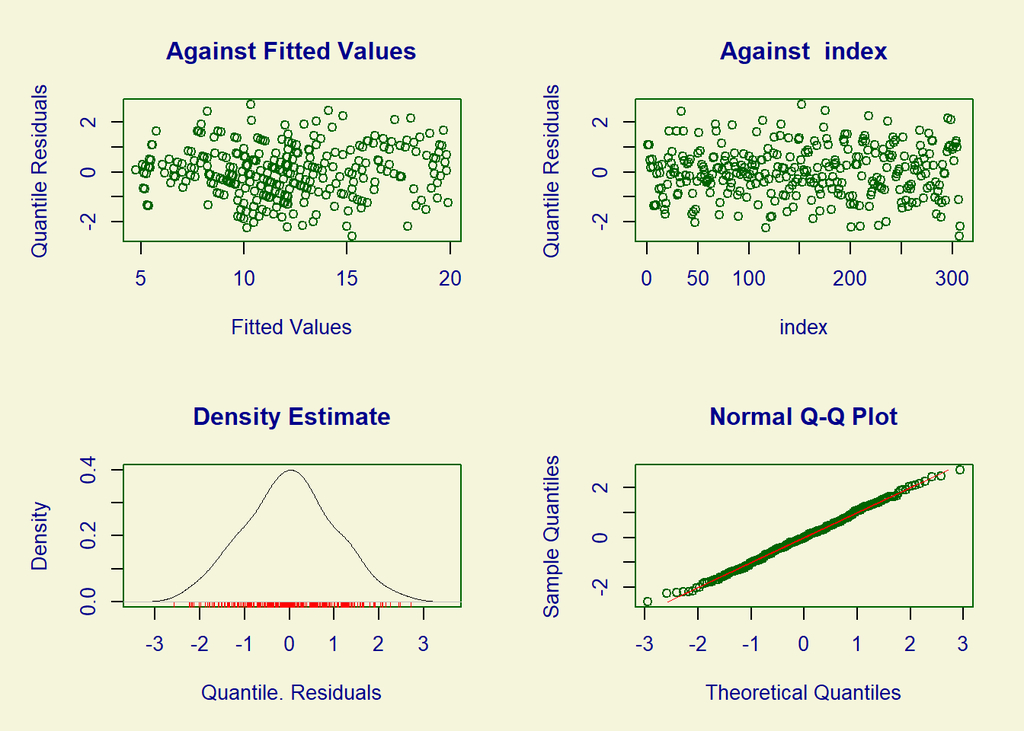

```
##        Summary of the Quantile Residuals
##                            mean   =  4.314702e-17
##                        variance   =  1.003257
##                coef. of skewness  =  0.02660023
##                coef. of kurtosis  =  2.684892
## Filliben correlation coefficient  =  0.998804
```

```r
plot(eg_normal)
```

The above example is repeated, this time using a Weibull Type 2 distribution.

```r
eg_weibull2 <- PersonAlytic(data=OvaryICT,
                ids="Mare",
                dvs="follicles",
                phase="Phase",
                time="Time",
                family=WEI2(),
                package="gamlss",
                autoDetect=NULL)
```

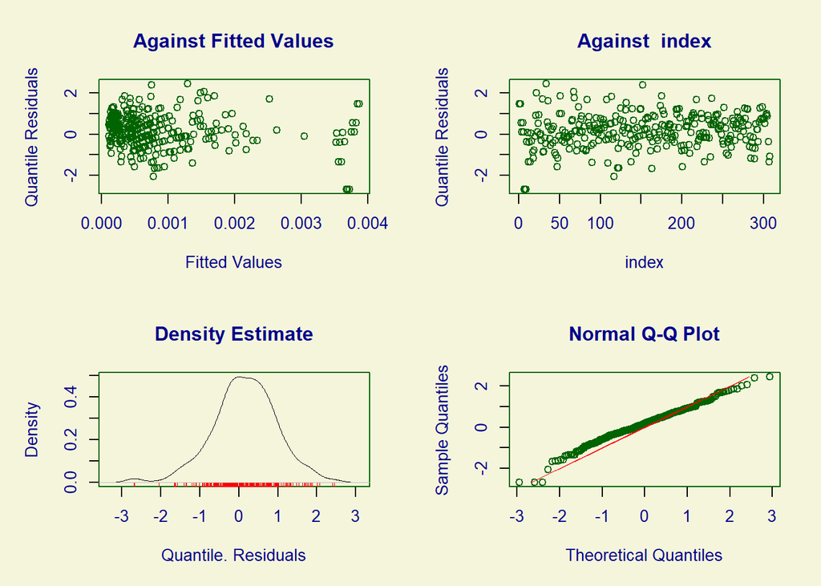

```
##        Summary of the Quantile Residuals
##                            mean   =  0.1554844
##                        variance   =  0.680279
##                coef. of skewness  =  -0.2875389
##                coef. of kurtosis  =  3.794029
## Filliben correlation coefficient  =  0.9942695
```

```r
plot(eg_weibull2)
```

Model comparisons can be implemented to automatically select the best fitting distribution using the approach implemented in the `fitDist` function of the `gamlss` package. See the section on the `autoDetect` parameter.

## Subgroup Analysis

If the user wants the model to be fit to a subset of the data, use the `subgroup` parameter. A logical (true/false) or binary (0/1) vector can be used to specify which cases to use. For example, we can restrict the analysis to the first 5 mares using the following:

```r
eg_subgroup <- PersonAlytic(data=OvaryICT,
                ids="Mare",
                dvs="follicles",
                phase="Phase",
                time="Time",
                subgroup=OvaryICT$Mare<6,
                autoDetect=NULL)
```

where the code `OvaryICT$Mare<6` creates a logical vector which is true if the mare id is less than 6.

## Variable Standardization

Variable standardization (mean zero and unit variance) is facilitated using the `standardize` parameter which is a list with three options that can be set to `TRUE` or `FALSE` (the default for all three is `FALSE`):

- `dv`: if set to `TRUE`, the dependent variable is standardized. If there are multiple dependent variables in `dvs`, each dependent variable will be standardized.
- `ivs`: if set to `TRUE`, the the independent variables in `ivs` and `target_ivs` are standardized.
- `byids`: if set to `TRUE`, standardization is done within each individual. This option should be set to `TRUE` if `individual_mods=TRUE` (this parameter is discussed below).

Here is an example where the target independent variables are standardized. This is useful for determining which target independent variable has the largest effect size since standardization put their respective effect sizes on the same scale. On continuous variables should be standardized.

```r
eg_standardize <- PersonAlytic(data=OvaryICT,
                ids="Mare",
                dvs="follicles",
                phase="Phase",
                time="Time",
                target_ivs=list("Target1", "Target2", "Target3"),
                standardize=list(dv=FALSE, ivs=TRUE, byids=FALSE),
                autoDetect=NULL)
```

```
##
## PersonAlytics is standardizing the variables in `targe_ivs`.
```

```
##
##
## Fitting models of the dependent variable `follicles` for 11 cases in `Mare`
##  and for 3 target indepented variables in `target_ivs`.
```

```
##
##
## Model fitting for the dependent variable `follicles` took:
##  Time difference of 14.28197 secs.
```

## Estimation Methods

A challenge of single subject and small sample mixed effect modeling is a lack of statistical power. One result of research in this area recommends that model comparisons be made using maximum likelihood (ML) estimation, while final model results should be estimated using restricted maximum likelihood (REML). The autodetection options detailed below use ML model comparisons by default, and final results reported in the output are estimated using REML by default. This cannot be changed, but for a single model without autodetection, the `method` parameter can be used select ML instead of REML:

```r
eg_method <- PersonAlytic(data=OvaryICT,
                ids="Mare",
                dvs="follicles",
                phase="Phase",
                time="Time",
                method="ML",
                autoDetect=NULL)
```

## Dealing with Invalid Variable Names

If the names of the target predictors in `target_ivs` had to be edited to make valid variable names (see `?make.names`), this parameter allows the user to put the illegal characters back in for the row variable names in high throughput output. For example, if the original variable name was “17.00_832.2375m/z”, a letter would need to prefix the variable name and the “/” would need to be replaced with another character, e.g., “X17.00_832.2375m.z”. To get the row names of the output back to original variable name, use `charSub=list(c("X", ""), c("m.z", "m/z"))`.

Note that inputs to `charSub` must be in double quotes and are case sensitive. All duplicates will be substituted. For example, if the variable name was “X1X23.x” and charSub=list(c(“X”, “”)), the resulting row label for this variable would be “123.x”.

## Type I Error or False Discovery Rate Adjustment

For high throughput analyses, we recommend selecting either a Type I error rate adjustment (such as Bonferonni) or a False Discovery Rate (FDR) adjustments (such as the method of Benjamini, Hochberg, and Yekutieli). This is implemented using the `p.method` parameter which takes on any value available in the `?p.adjust` function. In conjunction with the `p.method` is the Type I error rate `alpha`, which has a default of .05. Here is an example using the method of Benjamini, Hochberg, and Yekutieli (`p.method=BY`) and a Type I error rate of .1, adjusting for the FDR across the three predictors in `target_ivs`. If there are multiple dependent variables in `dvs`, adjustments are made across target independent variables within each dependent variable. If `individual_mods=TRUE`, adjustments are made across target independent variables within each dependent variable.

```r
eg_p.method <- PersonAlytic(data=OvaryICT,
                ids="Mare",
                dvs="follicles",
                phase="Phase",
                time="Time",
                target_ivs=list("Target1", "Target2", "Target3"),
                p.method='BY',
                alpha=.1,
                autoDetect=NULL
                )
```

```
##
##
## Fitting models of the dependent variable `follicles` for 11 cases in `Mare`
##  and for 3 target indepented variables in `target_ivs`.
```

```
##
##
## Model fitting for the dependent variable `follicles` took:
##  Time difference of 15.18295 secs.
```

## Phase Alignment

The `alignPhase` parameter provides options for aligning the time variable with the phase variable.

1. `alignPhase='none'` is the default and the time variable is left as-is.
2. `alignPhase='align'` aligns the time variable at the transition from the first and second phase within each participant. This alignment makes it so the effect at time=0 is the start of the second phase. For example, if the second phase starts at time 6 for participant A, and at time 8 for participant B, and there are 15 time points for each starting at 1:
   - Participant A’s resulting time variable will be -5, -4, -3, -2, -1, 0, 1, 2, 3, 4, 5, 6, 7, 8, 9.
   - Participant B’s resulting time variable will be -7, -6, -5, -4, -3, -2, -1, 0, 1, 2, 3, 4, 5, 6, 7.
3. `alignPhase='piecewise'` create a piecewise straight-line growth model within each phase. This option can be use to simplify complex trajectories when the within-phase trajectory is approximately linear within each phase. Although this may make results easier to interpret than a curvelinear model (e.g., when O=3), the piecewise model may have many more random effects and therefore be less parsimonious than a model with polynomial time. If `alignPhase='piecewise'`, the `TO` option of the `autodDetect` parameter and the `time_power` parameter are ignored.

## Finite Population Correction

A finite population correction (FPC) can be made if the size of the population from which the user’s sample originated is known. As an example, population sizes may be known for rare diseases. The parameter `fpc` has a default of 0, which turns off the FPC. If the user’s population size is known, set `fpc` to the population size. In this example, the population size is set to 6,000.

A finite population correction (FPC) can be used when the sample more than 5% of the population without replacement. In this situation the central limit theorem doesn’t hold and the standard errors of the user’s parameter estimates will be to large. Before illustrating how to implement a finite population correction, we first discuss the conditions under which a finite population correction may make a difference in a power analysis. This will only occur in situation where a large number of the `B` replications have p-values just larger than alpha and the FPC results in these p-values being less than alpha. In our experience, we rarely run into conditions where this is the case. The p-value distributions are usually smoothly positively skewed or near uniform. Neither of this distributions puts enough p-values near alpha for the FPC to have a large effect on power. This isn’t to say users shouldn’t apply the FPC for real data analyses using the `PersonAlytics` package, only that they should not expect the FPC to yield large improvement in power.

The argument `fpc` can be set to the user’s finite population size and an FPC will be included in the analyses and output.

```r
eg_fpc <- PersonAlytic(data=OvaryICT,
                ids="Mare",
                dvs="follicles",
                phase="Phase",
                time="Time",
                ivs=list("Target1", "Target2", "Target3"),
                fpc=6000,
                autoDetect=NULL
                )
```

Preliminary simulation studies have found that on average, the FPC generally reduces standard errors, but only by a small amount.

## Processors for Paralellization

The `cores` option allows the user to specify how many processors (or cores) on their computer can be devoted to a high throughput `PersonAlytic` run. By default, `PersonAlytic` detects the number of cores and uses one fewer than are on the machine. This allows the user to still do other work. If the user has a machine dedicated to analyses that won’t be needed until analyses are completed, setting the the number of cores to the maximum available will reduce computation time. Do not set this value to a number greater than the number of processors on the user’s machine or it may cause R or the user’s computer to crash. To determine the number of cores the user has, type the following into the R console:

```r
parallel::detectCores()
```

[output not shown]